# Rangkuman data gojek

Ujang fahmi

7/24/2018

# 1 Intro

Untuk mengetahui konsep publicness yang muncul melalui keberadaan transportasi online. Kami menggunakan studi kasus terhadap keberadaan gojek yang muncul sejak tahun 2015. Oleh karena itu, data yang digunakan dalam penelitian ini berasal dari beberapa sumber dengan kata kunci utama “go jek.” Dalam konteks ini data diambil dari: (1) Twitter; (2) Laman Change.org; (3) Platstore; dan (4) Media Online.

# 2 Twit tentang gojek

Data pertama diambil dari Twitter dengan beberapa parameter, yatu tagar **(1) #savedrivergojek; (2) #savegojek; (3) #saveojekonline;** dan **(4) twit yang menyebut (mention) akun @CeritaTranspOL**. Twit dengan parameter yang disebutkan tersebut dikumpulkan sejak tahun 2015 hingga 2018 dengan jumlah seperti dapat dilihat pada gambar berikut.

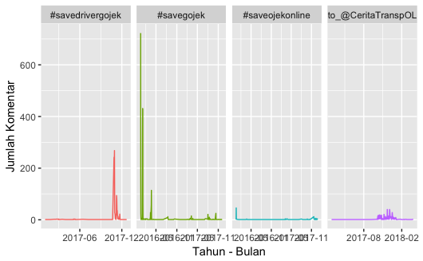

## 2.1 Jumlah akun pengirim

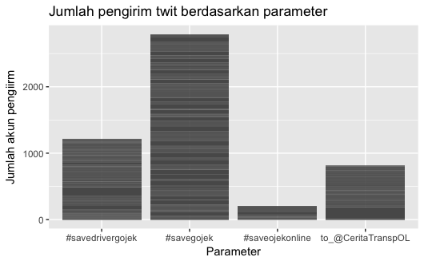

## 2.2 Akun pengirim paling banyak

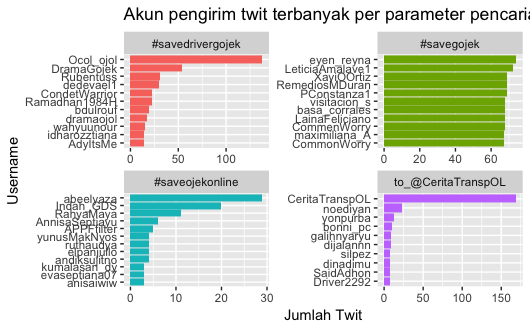

## 2.3 Jumlah akun terilibat

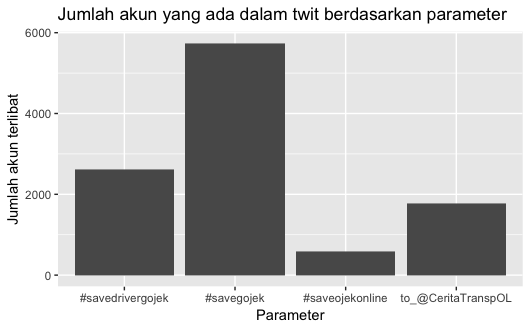

## 2.4 Akun paling sering terlibat

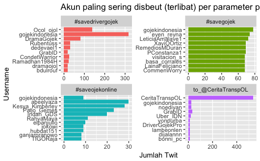

## 2.5 Topik yang dibahas

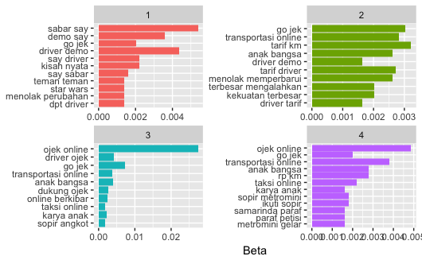

## 2.6 Close reading (CR) twit

### 2.6.1 CR Berdasar kata kunci

| date | tweets |
| --- | --- |
| 2015-12-19 | Yuk share apa saja sisi positif ojek online #SaveOjekOnline |
| 2015-12-18 | Untuk itu #SaveGojek perlu diluruskan sebgaimana Hukum Positif di negeri ini benar2 diluruskan mengingat lahan pkerjaan yg mash minim . |

### 2.6.2 CR Berdasar akun

| user | date | tweets |
| --- | --- | --- |
| ulinyusron | 2017-12-18 | Terima kasih banget Kang Irfan Dedy , pengemudi @gojekindonesia yang susah payah mengembalikan iPhone kesayangan yang tertinggal di motor . Jujur , tulus dan tanpa pamrih (menolak dikasih tips ngembal… |

### 2.6.3 CR Berdasar parameter + kata kunci

| user | date | tweets |
| --- | --- | --- |
| OjatSmith | 2016-03-27 | I am Gojekers #gojek #gojekindonesia #savegojek @ Gedung DPR /MPR -DPD RI |
| ttmsrsw | 2016-10-10 | 3km krn berasa kejauhan buat gojeknya . kalo hujan , tunggu berhenti dulu br order . #savegojek |
| dhenian69 | 2015-12-19 | SaveGojek !!! #SaveGojek |
| r_wicaksono | 2015-12-19 | Sehubungan dengan rencana mogok MreotMini Senin , dihimbau armada nGojek bisa ditambah & disiagakan :D #SaveGojek |
| andrimardiah | 2015-12-18 | (1 ) Kalau dari sudut pandangku , yang disave bukan gojeknya #SaveGojek , tpi keselamatan pemakai jasa dan ribuan tukang ojek yg mencari nafkah |

### 2.6.4 CR Berdasar tahun + kata kunci

| user | tahun | tweets |
| --- | --- | --- |
| OjatSmith | 2016 | I am Gojekers #gojek #gojekindonesia #savegojek @ Gedung DPR /MPR -DPD RI |
| ttmsrsw | 2016 | 3km krn berasa kejauhan buat gojeknya . kalo hujan , tunggu berhenti dulu br order . #savegojek |

# 3 Petisi tentang gojek

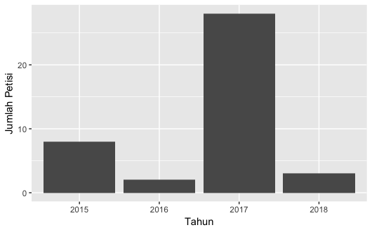

## 3.1 Perkembangan Jumlah Penandatangan

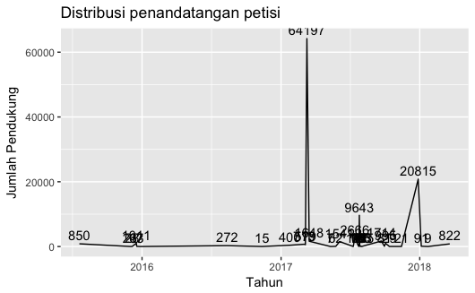

## 3.2 Top 10 Petisi

| title | jml_pendukung |
| --- | --- |
| JANGAN KEMBALI RENGGUT KEBEBASAN MASYARAKAT JAWA BARAT UNTUK MEMILIH TRANSPORTASI! | 64197 |
| Hentikan Permenhub 108 | 20815 |
| Tolak Pencabutan GoJek Tasikmalaya! | 9643 |
| DUKUNG KEBERADAAN GO-JEK DI PURWOKERTO | 2666 |
| Ijinkan Go-Jek Beroperasi di Wilayah Kabupaten Banyumas | 1714 |
| Kami Membutuhkan Gojek | 1648 |
| Perbaiki Sistem Gojek Yang Merugikan Driver | 1541 |
| Cabut larangan pengoperasian layanan transportasi berbasis online (Gojek, GrabBike,dll) | 1011 |
| Laporkan Sdr. Rian opang jatinangor | 995 |
| Pengelola Apartemen Kalibata City Harus Melindungi Hak Penghuni Atas Akses Transportasi - Gojek dan | 850 |

## 3.3 Topik komentar petisi

[figure not shown]

**Keterangan:**

1. petisi1 = Cabut larangan pengoperasian layanan transportasi berbasis online (Gojek, grabbike,dll)
2. petisi2 = Tolak Pencabutan gojek Tasikmalaya!
3. petisi3 = Jangan kembali renggut kebebasan masyarakat jawa barat untuk memilih transportasi!
4. petisi4 = Kami membutuhkan gojek
5. petisi5 = Dukung keberadaan gojek di purwokerto
6. petisi6 = Hentikan permenhub 108

## 3.4 Close reading (CR) petisi

### 3.4.1 CR Berdasar kata kunci petisi

| Nama | Waktu | Alasan |
| --- | --- | --- |
| fifie fifie | 2 thn yang lalu | saya selalu merasa diuntungkan dengan adanya GoJek , belum pernah sy merasakan kerugiannya. Pesan makanan saat lapar pun mudah tdk perlu keluar bermacet2an. kalau dilarang siapa yang gantiin? Pak Jona… |
| Aprilia Josephine | 2 thn yang lalu | Saya sangat terbantu untuk pergi ke mana2 karena sangat hemat dan praktis dgn menggunakan layanan ojek online. Menurut saya, sebaiknya Menteri Jonan tidak mengurusi hal2 yg tidak menimbulkan masalah, … |
| UMI DANIA | 2 thn yang lalu | Hey Jonan, mangkanya jangan naik mobil pribadi mulu! Cobain susahnya jadi RAKYAT! |

### 3.4.2 CR Berdasar judul + kata kunci petisi

| Nama | Waktu | Alasan |
| --- | --- | --- |
| modolhela aing | 2 thn yang lalu | banyak angkutan umum lebih amburadul. tp gak ada tindakan tegas .... Menteri yg aneh |
| jack betawi | 2 thn yang lalu | pendaringan nasi gue dari sini pak menteri.. Kalo situ mah enak bikin aturan gak dipikirin jangka panjangnya |

# 4 Playstore

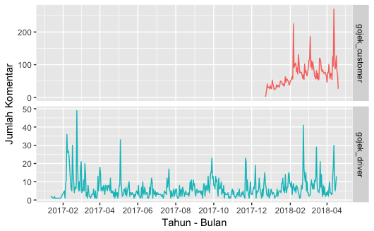

## 4.1 Topik yang dibahas customer

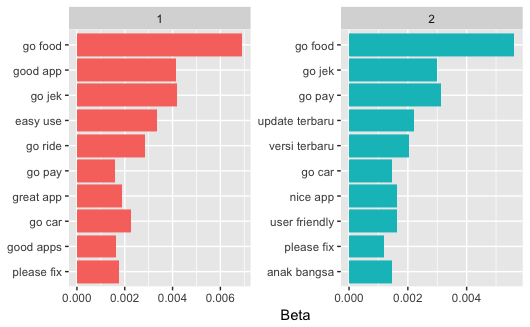

## 4.2 Close reading Customer

### 4.2.1 Close reading kata kunci Customer

| username | date | text |
| --- | --- | --- |
| Fathimah Azzahra | 2018-04-18 | Fitur chat jgn di ilangin pake fitur chatnya itu sngt membantu kami |
| RINTO LEE | 2018-04-18 | Fitur chat nya klo bisa ngirim foto lebih enak |
| evi raudha | 2018-04-16 | Ga suka aplikasi versi sekarang diluar fitur chat sering ngelag searching map lama jam plg kantor aplikasi sering error please fix it Klo gini terus bisa pindah kelain hati |
| Ricky FM | 2018-04-07 | Sangat bagus dan terima kasih sdh merespon request sy tentang fitur chat yg memudahkan komunikasi antara driver dgn customer tdk perlu SMS atau Call Alhasil sdh ad fitur chat |
| aristya | 2018-04-05 | Belum bisa menggunakan fitur chat karena drivernya belum update |

### 4.2.2 Close reading tahun + kata kunci Customer

| username | tahun | text |
| --- | --- | --- |
| Pradika Ferhan | 2018 | Server is always down and error Can t even book a ride with this constant error And it isn t because of my network because it works perfectly fine with other similar application Please fix this issue … |
| Dimas Jatikusumo | 2018 | NA |
| Rapty Axa | 2018 | Stupid app Why does it pair me with a driver that is close by radius but FAR AWAY by total distance distance driveable route road This mechanism is very weak and prone to miscalculation This is so dum… |
| Dania Putri | 2018 | App error tau tau logout sendiri Mau login pake verifikasi sms tapi ditungguin gaada sms masuk sama sekali tau tau ada sekitar 4 driver yang ngehubungin saya nanya posisi meanwhile saya ga mesen sama … |
| Steffanie Anggie | 2018 | Ssemakin ksini app semakin sering error barusan aja ak play token 17 kali transaksi tp poinnya ga masuk masuk Plis d perbaiki |

## 4.3 Topik yang dibahas driver

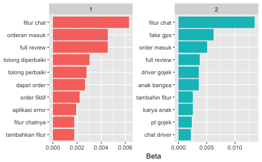

## 4.4 Close reading Mitra

### 4.4.1 CR berdasarkan kata kunci

| date | text |
| --- | --- |
| 2018-03-19 | Tolong tambahkan fitur chatting di gosend gofood dll |
| 2018-02-28 | Fitur chatnya knapa hanya di goride aja |
| 2018-03-08 | Fitur chat saat para driver tidak ada pulsa utk telp dan sms itu sudah sngat bagus. Namun fitur penilaian para driver utk para customernya tdk ada. Padahal sekitar 77% customer tdk menunjukkn empati n… |
| 2018-03-06 | Mau nanya dong ko fitur chat nya di aplikasi gua blm ada ya pdhl udh di perbaharui? |
| 2018-03-14 | Tolong untuk yang go send go food di kasih fitur chat. Biar gak nanggung. |

### 4.4.2 CR berdasar tahun + kata kunci driver

| username | tahun | text |
| --- | --- | --- |
| andi setyawan | 2017 | Tolong update supaya gps ngezoom kalo tujuan sudah dekat dan selalu di titik tengah dotsnya |
| DWI RAHMANSYAH | 2017 | - Mohon perbaiki segala system dari yang semula hanya compatible google maps beralihlah ke google earth supaya terpantau batas daerah yang di batasi sungai yang luas. - Syncron kan GPS android driver … |
| diaz putra | 2017 | Servernya konyol Buat apa update kl msh bisa nyari orderan pakek versi jadul Kalah sama aplikasi game online Trus gak bisa detect fake gps Gak ada fitur chat in app pula |
| Ruly Alkurnianto | 2017 | Banyak fake gps min |

# 5 Media online

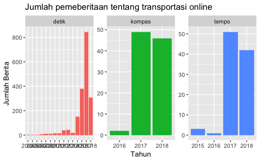

## 5.1 Frame berita

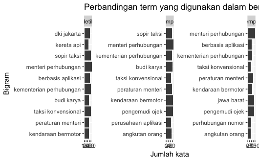

## 5.2 Topik dari kompas

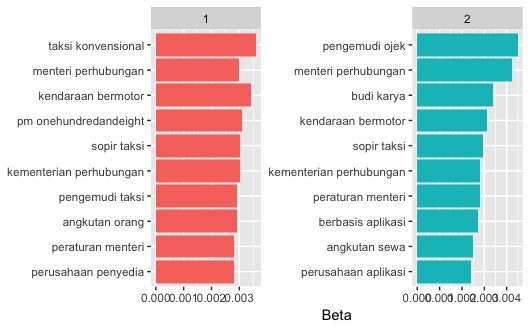

## 5.3 Close reading kompas

| tanggal | konten |
| --- | --- |
| 2018-04-01 | SOLO, KOMPAS.com - Perusahaan penyedia aplikasi transportasi online akan diwajibkan terdaftar di Kementerian Perhubungan sebagai perusahaan transportasi.Menteri Perhubungan Budi Karya Sumadi mengataka… |

## 5.4 Topik dari tempo

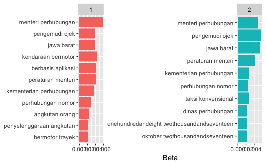

## 5.5 Close reading tempo

| tanggal | konten |
| --- | --- |
| 2017-10-19 | TEMPO.CO, Jakarta - Pemerintah mengumumkan rumusan revisi peraturan Peraturan Menteri Perhubungan Nomor 26 Tahun 2017 tentang Penyelenggaraan Angkutan Orang Dengan Kendaraan Bermotor Umum Tidak Dalam … |

## 5.6 Topik dari detik

[figure not shown]

## 5.7 Close reading detik

| tanggal | konten |
| --- | --- |
| 2018-05-09 | Jakarta - Badan Pengelola Transportasi Jabodetabek BPTJ, Korlantas Polri, dan Dinas Perhubungan DKI Jakarta, bersama mitra pengemudi GrabCar menggelar sosialisasi aturan ganjil genap kendaraan roda em… |